# CUNY - DS Maths - Final Project

Kishore Prasad

November 27, 2015

Lets first prepare the environment to use hflights data

```r
#install.packages("hflights")
library(hflights)
```

Assuming that my X variable is DepDelay and Y variable is ArrDelay, we calculate the 3rd Quartile of DepDelay and 2nd Quartile of ArrDelay as below

```r
DD_3Q <- quantile(hflights$DepDelay, na.rm = TRUE)[4]
AD_2Q <- quantile(hflights$ArrDelay, na.rm = TRUE)[3]
```

We now, create 2 additional columns that count the observations for being greater than or less than the 3Q and 2Q variables.

```r
fdata <- cbind(hflights[ ,c("DepDelay", "ArrDelay")], A = ifelse(hflights$DepDelay>DD_3Q,1,0), B = ifelse(hflights$ArrDelay>AD_2Q,1,0) )

tbl <- table(fdata$A, fdata$B)
tbl
```

```
##
##          0      1
##   0 113141  55554
##   1   3813  51366
```

Using this table, we now generate the probabilities table as below:

```r
p<- tbl[1,1]
q<- tbl[1,2]

r<- tbl[2,1]
s<- tbl[2,2]

prob_table <- matrix(data=0,nrow=3, ncol=3)

prob_table[1,1] <- p / (p+q+r+s)
prob_table[1,2] <- q / (p+q+r+s)
prob_table[1,3] <- (p+q) / (p+q+r+s)

prob_table[2,1] <- r / (p+q+r+s)
prob_table[2,2] <- s / (p+q+r+s)
prob_table[2,3] <- (r+s) / (p+q+r+s)

prob_table[3,1] <- (p+r) / (p+q+r+s)
prob_table[3,2] <- (q+s) / (p+q+r+s)
prob_table[3,3] <- (p+q+r+s) / (p+q+r+s)

prob_table
```

```
##           [,1]      [,2]      [,3]
## [1,] 0.5053780 0.2481485 0.7535265
## [2,] 0.0170319 0.2294416 0.2464735
## [3,] 0.5224099 0.4775901 1.0000000
```

Using the prob_table, we will now answer the following questions:

```r
prob_table[2,2]
```

```
## [1] 0.2294416
```

```r
prob_table[2,3] * prob_table[3,2]
```

```
## [1] 0.1177133
```

```r
prob_table[1,2]
```

```
## [1] 0.2481485
```

```r
prob_table[1,3] * prob_table[3,2]
```

```
## [1] 0.3598768
```

generate the chisquare test

```r
chisq.test(tbl)
```

```
##
##  Pearson's Chi-squared test with Yates' continuity correction
##
## data:  tbl
## X-squared = 60308.3, df = 1, p-value < 2.2e-16
```

We can see from the above chi square output that the p-value is less than 0.05. we reject the null hypothesis that the Departure delay is independent of the arrival delay.

2. Descriptive and Inferential Statistics.

```r
library(psych)
describe(fdata)
```

```
##          vars      n mean    sd median trimmed   mad min max range skew
## DepDelay    1 224591 9.44 28.80      0    3.37  5.93 -33 981  1014 5.97
## ArrDelay    2 223874 7.09 30.71      0    1.85 13.34 -70 978  1048 5.04
## A           3 224591 0.25  0.43      0    0.18  0.00   0   1     1 1.17
## B           4 223874 0.48  0.50      0    0.47  0.00   0   1     1 0.09
##          kurtosis   se
## DepDelay    71.90 0.06
## ArrDelay    55.57 0.06
## A           -0.62 0.00
## B           -1.99 0.00
```

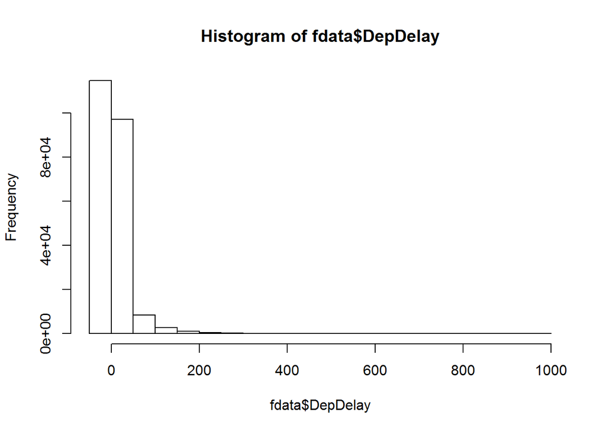

```r
hist(fdata$DepDelay)
```

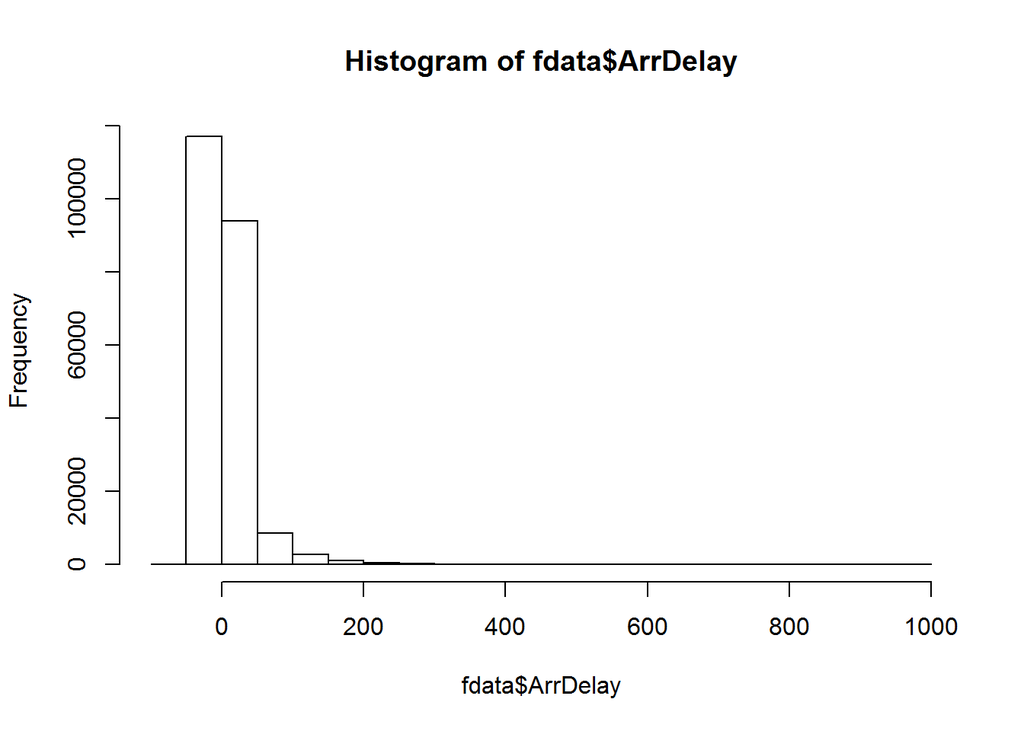

```r
hist(fdata$ArrDelay)
```

A scatterplot of the 2 variables is as below

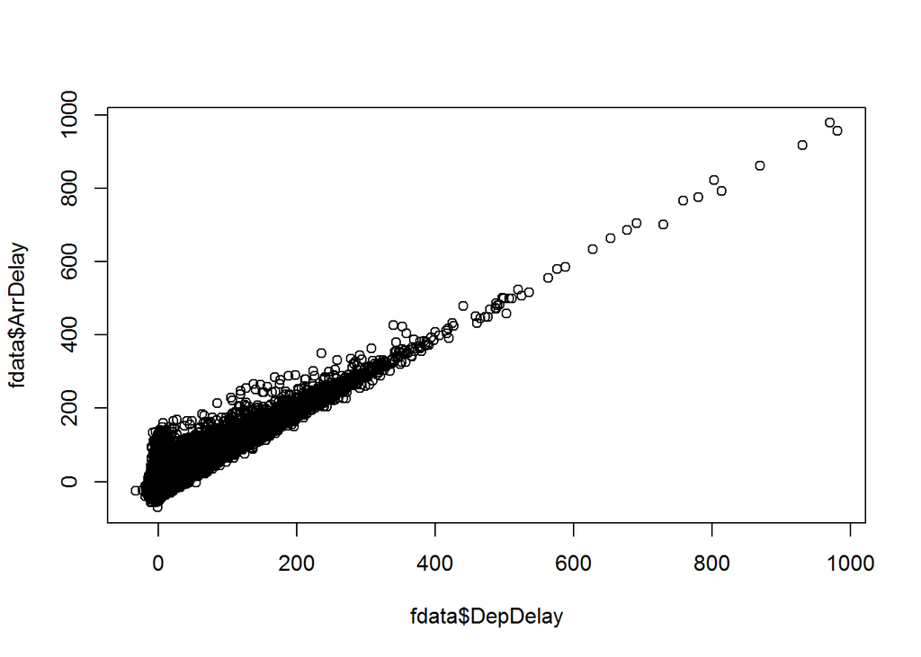

```r
plot(fdata$DepDelay, fdata$ArrDelay)
```

We will now generate the correlation matrix

```r
mat1 <- matrix(table(fdata$A), nrow=1, ncol=2)
mat2 <- matrix(table(fdata$B), nrow=1, ncol=2)
cor_mat <- cor(mat1,mat2)
cor_mat
```

```
##      [,1] [,2]
## [1,]   NA   NA
## [2,]   NA   NA
```

Provide a 95% CI for the difference in the mean of DepDelay and ArrDelay.

```r
N=nrow(fdata)
mean_depDelay <- mean(fdata$DepDelay, na.rm = TRUE)
mean_arrDelay <- mean(fdata$ArrDelay, na.rm = TRUE)

var_depDelay <- var(fdata$DepDelay, na.rm = TRUE)
var_arrDelay <- var(fdata$ArrDelay, na.rm = TRUE)

MSE <- (var_depDelay + var_arrDelay) / 2

sm1_m2 <- sqrt(2 * MSE / N)
sm1_m2
```

```
## [1] 0.08827261
```

```r
mean_diff <- mean_depDelay - mean_arrDelay
mean_diff
```

```
## [1] 2.350617
```

```r
tCL <- 2.074

lower_limit_95 <- mean_diff - (tCL * sm1_m2)
lower_limit_95
```

```
## [1] 2.167539
```

```r
upper_limit_95 <- mean_diff + (tCL * sm1_m2)
upper_limit_95
```

```
## [1] 2.533694
```

We will now generate the correlation matrix for the variables depdelay and arrdelay as follows:

```r
cor_mat <- cor(fdata[1:2], use="complete.obs", method = "pearson")
cor_mat
```

```
##           DepDelay  ArrDelay
## DepDelay 1.0000000 0.9292181
## ArrDelay 0.9292181 1.0000000
```

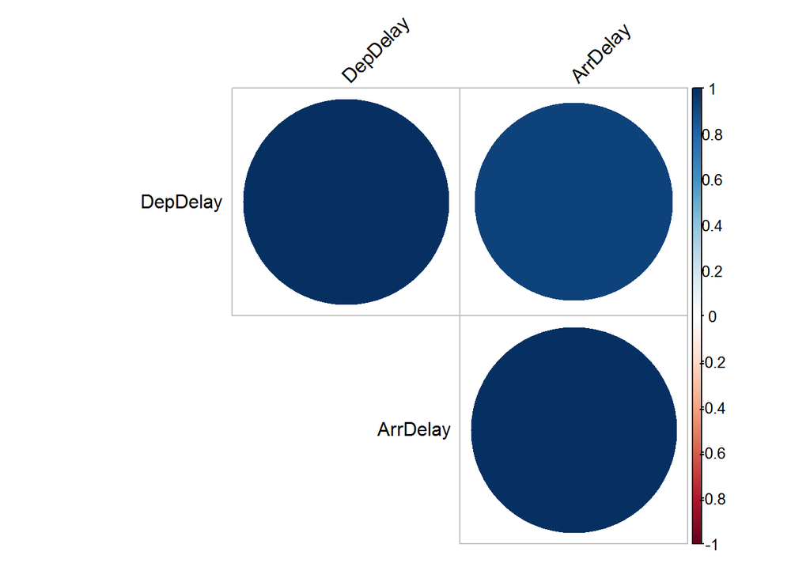

```r
library(corrplot)
corrplot(cor_mat, type="upper", order="hclust", tl.col="black", tl.srt=45)
```

As we can see from the above correlation matrix, there is a strong positive correlation between depdelay and arrdelay.

```r
cor_mat
```

```
##           DepDelay  ArrDelay
## DepDelay 1.0000000 0.9292181
## ArrDelay 0.9292181 1.0000000
```

```r
prec_mat <- solve(cor_mat)
prec_mat
```

```
##           DepDelay  ArrDelay
## DepDelay  7.323130 -6.804785
## ArrDelay -6.804785  7.323130
```

```r
A <- cor_mat
B <- prec_mat

AB <- A %*% B
AB
```

```
##          DepDelay ArrDelay
## DepDelay        1        0
## ArrDelay        0        1
```

```r
BA <- B %*% A
BA
```

```
##          DepDelay ArrDelay
## DepDelay        1        0
## ArrDelay        0        1
```

Shift values so that the minumum value is above zero

```r
fdata <- cbind(fdata, depDelay_shift = fdata$DepDelay - min(fdata$DepDelay, na.rm=TRUE), arrDelay_shift = fdata$ArrDelay - min(fdata$ArrDelay, na.rm=TRUE) )

fdata$DepDelay <- fdata$DepDelay - min(fdata$DepDelay, na.rm=TRUE)
```

Lets now load the MASS package and fit an exponential pdf.

```r
library(MASS)
depdelay_fit <- fitdistr(fdata[is.na(fdata$depDelay_shift)==FALSE,"depDelay_shift"], "exponential")
```

Next find the optimal value of lamdba and take 1000 samples

```r
depdelay_fit <- fitdistr(fdata[is.na(fdata$depDelay_shift)==FALSE,"depDelay_shift"], "poisson")

depdelay_fit
```

```
##      lambda
##   42.44495104
##  ( 0.01374728)
```

```r
lambda <- as.numeric(depdelay_fit[1])

depdelay_samples <- rexp(1000, lambda)
```

Next we compare the histogram of the original variable with the sample

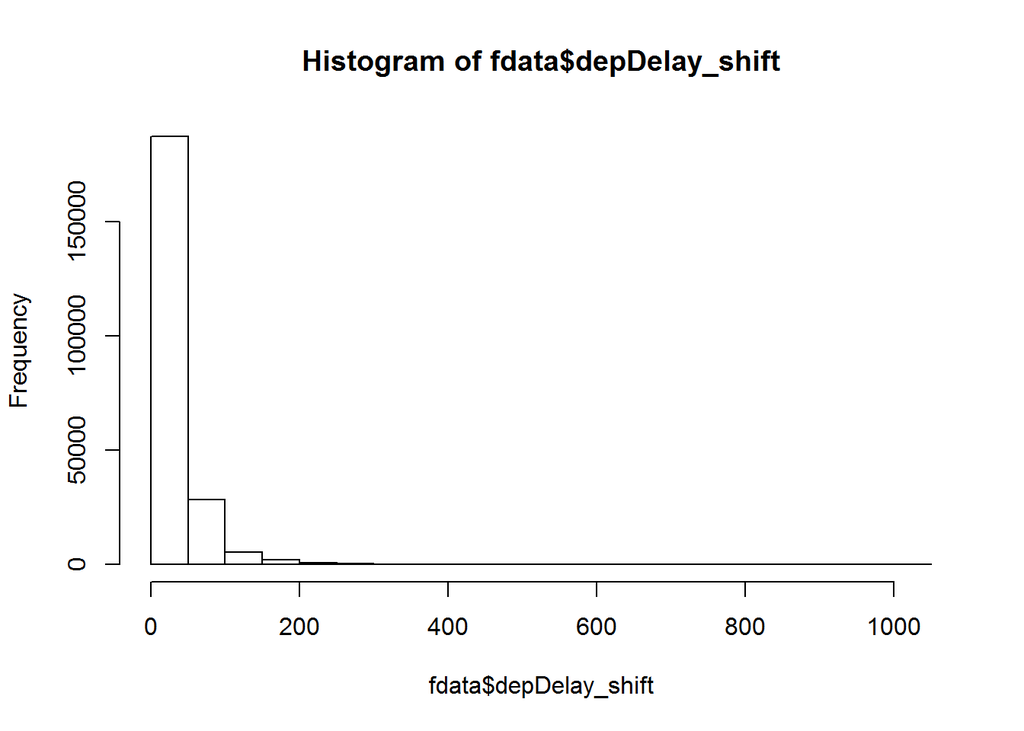

```r
hist(fdata$depDelay_shift)
```

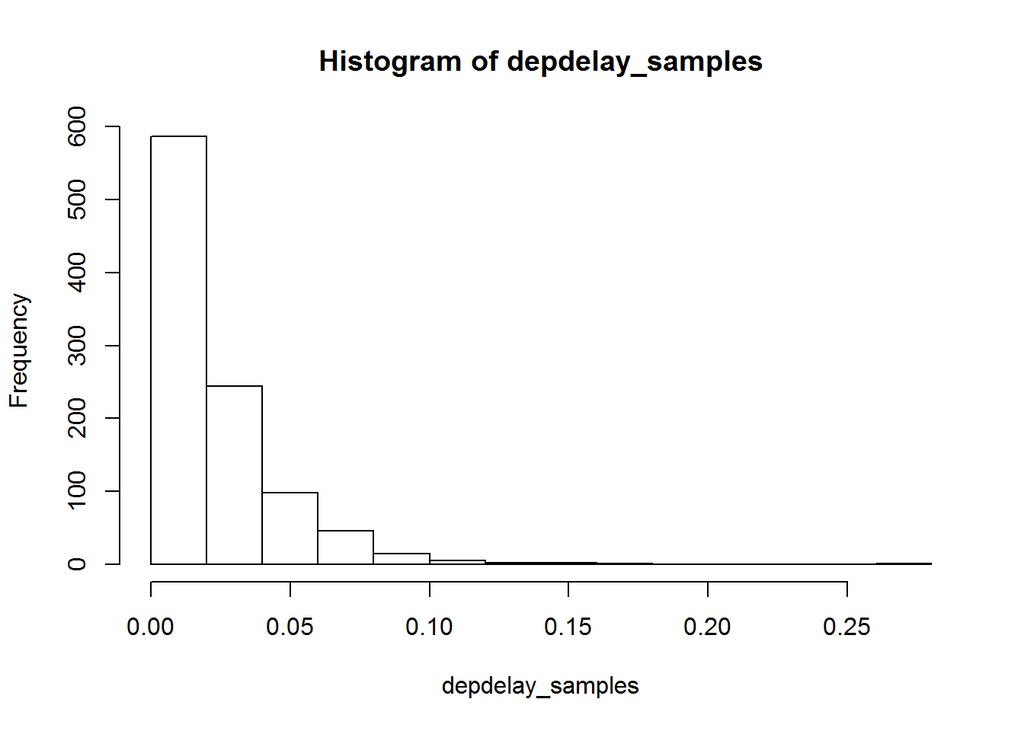

```r
hist(depdelay_samples)
```